# Risk Factor Analysis

## Outcome Variable

**Outcome Variable:** ever_wasted

## Predictor Variables

**Intervention Variable:** nhh

**Adjustment Set:**

- arm
- W_mage
- meducyrs
- feducyrs
- W_mhtcm
- W_mwtkg
- W_mbmi
- W_nrooms
- impfloor
- impsan
- safeh20
- delta_W_mage
- delta_meducyrs
- delta_feducyrs
- delta_W_mhtcm
- delta_W_mwtkg
- delta_W_mbmi
- delta_W_nrooms
- delta_impfloor
- delta_impsan
- delta_safeh20

## Stratifying Variables

The analysis was stratified on these variable(s):

- agecat
- studyid
- country

## Data Summary

| agecat | studyid | country | nhh | ever_wasted | n_cell | n |
| --- | --- | --- | --- | --- | --- | --- |
| 0-24 months | ki1000108-IRC | INDIA | 3 or less | 0 | 20 | 410 |
| 0-24 months | ki1000108-IRC | INDIA | 3 or less | 1 | 38 | 410 |
| 0-24 months | ki1000108-IRC | INDIA | 4-5 | 0 | 63 | 410 |
| 0-24 months | ki1000108-IRC | INDIA | 4-5 | 1 | 95 | 410 |
| 0-24 months | ki1000108-IRC | INDIA | 6-7 | 0 | 38 | 410 |
| 0-24 months | ki1000108-IRC | INDIA | 6-7 | 1 | 69 | 410 |
| 0-24 months | ki1000108-IRC | INDIA | 8+ | 0 | 20 | 410 |
| 0-24 months | ki1000108-IRC | INDIA | 8+ | 1 | 67 | 410 |
| 0-24 months | ki1000304b-SAS-FoodSuppl | INDIA | 3 or less | 0 | 24 | 418 |
| 0-24 months | ki1000304b-SAS-FoodSuppl | INDIA | 3 or less | 1 | 14 | 418 |
| 0-24 months | ki1000304b-SAS-FoodSuppl | INDIA | 4-5 | 0 | 95 | 418 |
| 0-24 months | ki1000304b-SAS-FoodSuppl | INDIA | 4-5 | 1 | 88 | 418 |
| 0-24 months | ki1000304b-SAS-FoodSuppl | INDIA | 6-7 | 0 | 66 | 418 |
| 0-24 months | ki1000304b-SAS-FoodSuppl | INDIA | 6-7 | 1 | 61 | 418 |
| 0-24 months | ki1000304b-SAS-FoodSuppl | INDIA | 8+ | 0 | 36 | 418 |
| 0-24 months | ki1000304b-SAS-FoodSuppl | INDIA | 8+ | 1 | 34 | 418 |
| 0-24 months | ki1017093-NIH-Birth | BANGLADESH | 3 or less | 0 | 58 | 624 |
| 0-24 months | ki1017093-NIH-Birth | BANGLADESH | 3 or less | 1 | 57 | 624 |
| 0-24 months | ki1017093-NIH-Birth | BANGLADESH | 4-5 | 0 | 134 | 624 |
| 0-24 months | ki1017093-NIH-Birth | BANGLADESH | 4-5 | 1 | 129 | 624 |
| 0-24 months | ki1017093-NIH-Birth | BANGLADESH | 6-7 | 0 | 72 | 624 |
| 0-24 months | ki1017093-NIH-Birth | BANGLADESH | 6-7 | 1 | 69 | 624 |
| 0-24 months | ki1017093-NIH-Birth | BANGLADESH | 8+ | 0 | 62 | 624 |
| 0-24 months | ki1017093-NIH-Birth | BANGLADESH | 8+ | 1 | 43 | 624 |
| 0-24 months | ki1017093b-PROVIDE | BANGLADESH | 3 or less | 0 | 98 | 700 |
| 0-24 months | ki1017093b-PROVIDE | BANGLADESH | 3 or less | 1 | 42 | 700 |
| 0-24 months | ki1017093b-PROVIDE | BANGLADESH | 4-5 | 0 | 211 | 700 |
| 0-24 months | ki1017093b-PROVIDE | BANGLADESH | 4-5 | 1 | 111 | 700 |
| 0-24 months | ki1017093b-PROVIDE | BANGLADESH | 6-7 | 0 | 94 | 700 |
| 0-24 months | ki1017093b-PROVIDE | BANGLADESH | 6-7 | 1 | 57 | 700 |

[output cut: 114 more lines]

The following strata were considered:

- agecat: 0-24 months, studyid: ki1000108-IRC, country: INDIA
- agecat: 0-24 months, studyid: ki1000304b-SAS-FoodSuppl, country: INDIA
- agecat: 0-24 months, studyid: ki1017093-NIH-Birth, country: BANGLADESH
- agecat: 0-24 months, studyid: ki1017093b-PROVIDE, country: BANGLADESH
- agecat: 0-24 months, studyid: ki1017093c-NIH-Crypto, country: BANGLADESH
- agecat: 0-24 months, studyid: ki1148112-LCNI-5, country: MALAWI
- agecat: 0-6 months, studyid: ki1000108-IRC, country: INDIA
- agecat: 0-6 months, studyid: ki1000304b-SAS-FoodSuppl, country: INDIA
- agecat: 0-6 months, studyid: ki1017093-NIH-Birth, country: BANGLADESH
- agecat: 0-6 months, studyid: ki1017093b-PROVIDE, country: BANGLADESH
- agecat: 0-6 months, studyid: ki1017093c-NIH-Crypto, country: BANGLADESH
- agecat: 0-6 months, studyid: ki1148112-LCNI-5, country: MALAWI
- agecat: 6-24 months, studyid: ki1000108-IRC, country: INDIA
- agecat: 6-24 months, studyid: ki1000304b-SAS-FoodSuppl, country: INDIA
- agecat: 6-24 months, studyid: ki1017093-NIH-Birth, country: BANGLADESH
- agecat: 6-24 months, studyid: ki1017093b-PROVIDE, country: BANGLADESH
- agecat: 6-24 months, studyid: ki1017093c-NIH-Crypto, country: BANGLADESH
- agecat: 6-24 months, studyid: ki1148112-LCNI-5, country: MALAWI

### Dropped Strata

Some strata were dropped due to rare outcomes:

- agecat: 0-6 months, studyid: ki1000304b-SAS-FoodSuppl, country: INDIA
- agecat: 0-6 months, studyid: ki1148112-LCNI-5, country: MALAWI

## Methods Detail

We’re interested in the causal parameters $E[Y_a]$ for all values of $a \in \mathcal{A}$. These parameters represent the mean outcome if, possibly contrary to fact, we intervened to set all units to have $A=a$. Under the randomization and positivity assumptions, these are identified by the statistical parameters $\psi_a=E_W[E_{Y|A,W}(Y|A=a,W)]$. In addition, we’re interested in the mean of $Y$, $E[Y]$ under no intervention (the observed mean). We will estimate these parameters by using SuperLearner to fit the relevant likelihood factors – $E_{Y|A,W}(Y|A=a,W)$ and $p(A=a|W)$, and then updating our likelihood fit using a joint TMLE.

For unadjusted analyses ($W=\{\}$), initial likelihoods were estimated using Lrnr_glm to estimate the simple $E(Y|A)$ and Lrnr_mean to estimate $p(A)$. For adjusted analyses, a small library containing Lrnr_glmnet, Lrnr_xgboost, and Lrnr_mean was used.

Having estimated these parameters, we will then use the delta method to estimate relative risks and attributable risks relative to a prespecified baseline level of $A$.

# Results Detail

## Results Plots

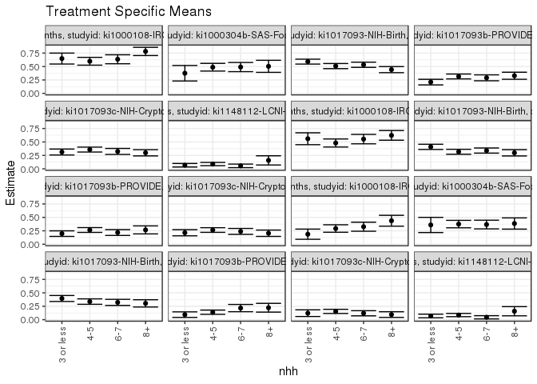

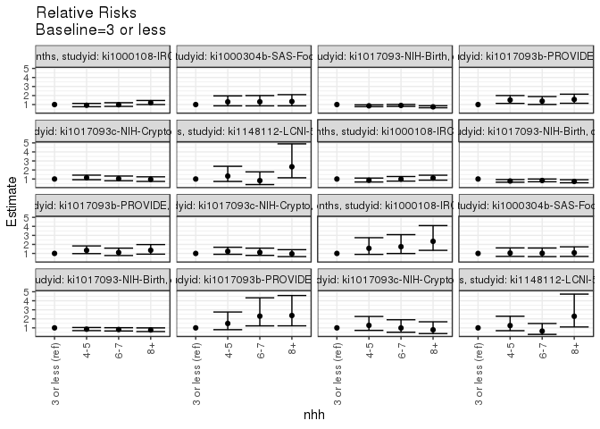

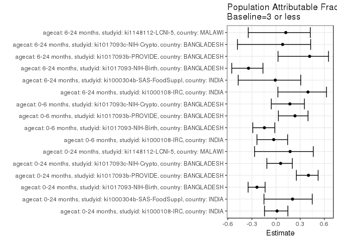

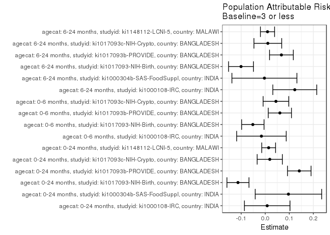

## Results Table

### Parameter: TSM

| agecat | studyid | country | intervention_level | baseline_level | estimate | ci_lower | ci_upper |
| --- | --- | --- | --- | --- | --- | --- | --- |
| 0-24 months | ki1000108-IRC | INDIA | 3 or less | NA | 0.6480322 | 0.5461616 | 0.7499027 |
| 0-24 months | ki1000108-IRC | INDIA | 4-5 | NA | 0.5981702 | 0.5257631 | 0.6705772 |
| 0-24 months | ki1000108-IRC | INDIA | 6-7 | NA | 0.6348143 | 0.5510343 | 0.7185943 |
| 0-24 months | ki1000108-IRC | INDIA | 8+ | NA | 0.7811157 | 0.7046967 | 0.8575346 |
| 0-24 months | ki1000304b-SAS-FoodSuppl | INDIA | 3 or less | NA | 0.3748795 | 0.2304917 | 0.5192674 |
| 0-24 months | ki1000304b-SAS-FoodSuppl | INDIA | 4-5 | NA | 0.4870882 | 0.4154195 | 0.5587569 |
| 0-24 months | ki1000304b-SAS-FoodSuppl | INDIA | 6-7 | NA | 0.4899699 | 0.4046653 | 0.5752745 |
| 0-24 months | ki1000304b-SAS-FoodSuppl | INDIA | 8+ | NA | 0.5033958 | 0.3913098 | 0.6154817 |
| 0-24 months | ki1017093-NIH-Birth | BANGLADESH | 3 or less | NA | 0.5910315 | 0.5453972 | 0.6366657 |
| 0-24 months | ki1017093-NIH-Birth | BANGLADESH | 4-5 | NA | 0.5081844 | 0.4605943 | 0.5557746 |
| 0-24 months | ki1017093-NIH-Birth | BANGLADESH | 6-7 | NA | 0.5326418 | 0.4843387 | 0.5809449 |
| 0-24 months | ki1017093-NIH-Birth | BANGLADESH | 8+ | NA | 0.4421586 | 0.3857100 | 0.4986072 |
| 0-24 months | ki1017093b-PROVIDE | BANGLADESH | 3 or less | NA | 0.2098434 | 0.1576781 | 0.2620086 |
| 0-24 months | ki1017093b-PROVIDE | BANGLADESH | 4-5 | NA | 0.3148665 | 0.2695401 | 0.3601928 |
| 0-24 months | ki1017093b-PROVIDE | BANGLADESH | 6-7 | NA | 0.2898828 | 0.2347888 | 0.3449768 |
| 0-24 months | ki1017093b-PROVIDE | BANGLADESH | 8+ | NA | 0.3282960 | 0.2626021 | 0.3939900 |
| 0-24 months | ki1017093c-NIH-Crypto | BANGLADESH | 3 or less | NA | 0.3123161 | 0.2564851 | 0.3681471 |
| 0-24 months | ki1017093c-NIH-Crypto | BANGLADESH | 4-5 | NA | 0.3580292 | 0.3124539 | 0.4036045 |
| 0-24 months | ki1017093c-NIH-Crypto | BANGLADESH | 6-7 | NA | 0.3234068 | 0.2674106 | 0.3794031 |
| 0-24 months | ki1017093c-NIH-Crypto | BANGLADESH | 8+ | NA | 0.2983013 | 0.2403293 | 0.3562733 |
| 0-24 months | ki1148112-LCNI-5 | MALAWI | 3 or less | NA | 0.0666548 | 0.0340366 | 0.0992731 |
| 0-24 months | ki1148112-LCNI-5 | MALAWI | 4-5 | NA | 0.0883040 | 0.0581451 | 0.1184629 |
| 0-24 months | ki1148112-LCNI-5 | MALAWI | 6-7 | NA | 0.0549107 | 0.0217950 | 0.0880264 |
| 0-24 months | ki1148112-LCNI-5 | MALAWI | 8+ | NA | 0.1569027 | 0.0714928 | 0.2423126 |
| 0-6 months | ki1000108-IRC | INDIA | 3 or less | NA | 0.5598403 | 0.4494061 | 0.6702745 |
| 0-6 months | ki1000108-IRC | INDIA | 4-5 | NA | 0.4806320 | 0.4057586 | 0.5555054 |
| 0-6 months | ki1000108-IRC | INDIA | 6-7 | NA | 0.5530377 | 0.4650342 | 0.6410413 |
| 0-6 months | ki1000108-IRC | INDIA | 8+ | NA | 0.6225006 | 0.5321843 | 0.7128169 |
| 0-6 months | ki1017093-NIH-Birth | BANGLADESH | 3 or less | NA | 0.4085400 | 0.3600629 | 0.4570171 |
| 0-6 months | ki1017093-NIH-Birth | BANGLADESH | 4-5 | NA | 0.3172426 | 0.2713392 | 0.3631460 |
| 0-6 months | ki1017093-NIH-Birth | BANGLADESH | 6-7 | NA | 0.3396876 | 0.2921065 | 0.3872688 |
| 0-6 months | ki1017093-NIH-Birth | BANGLADESH | 8+ | NA | 0.2978615 | 0.2392765 | 0.3564464 |
| 0-6 months | ki1017093b-PROVIDE | BANGLADESH | 3 or less | NA | 0.1977487 | 0.1457011 | 0.2497964 |
| 0-6 months | ki1017093b-PROVIDE | BANGLADESH | 4-5 | NA | 0.2649762 | 0.2202165 | 0.3097359 |
| 0-6 months | ki1017093b-PROVIDE | BANGLADESH | 6-7 | NA | 0.2182696 | 0.1641069 | 0.2724323 |
| 0-6 months | ki1017093b-PROVIDE | BANGLADESH | 8+ | NA | 0.2670454 | 0.1926919 | 0.3413989 |
| 0-6 months | ki1017093c-NIH-Crypto | BANGLADESH | 3 or less | NA | 0.2141814 | 0.1569478 | 0.2714150 |
| 0-6 months | ki1017093c-NIH-Crypto | BANGLADESH | 4-5 | NA | 0.2644489 | 0.2213632 | 0.3075346 |
| 0-6 months | ki1017093c-NIH-Crypto | BANGLADESH | 6-7 | NA | 0.2390828 | 0.1840419 | 0.2941237 |
| 0-6 months | ki1017093c-NIH-Crypto | BANGLADESH | 8+ | NA | 0.2050959 | 0.1460104 | 0.2641815 |
| 6-24 months | ki1000108-IRC | INDIA | 3 or less | NA | 0.1869509 | 0.0922186 | 0.2816832 |
| 6-24 months | ki1000108-IRC | INDIA | 4-5 | NA | 0.2928379 | 0.2232419 | 0.3624338 |
| 6-24 months | ki1000108-IRC | INDIA | 6-7 | NA | 0.3262775 | 0.2422134 | 0.4103417 |
| 6-24 months | ki1000108-IRC | INDIA | 8+ | NA | 0.4374144 | 0.3362789 | 0.5385498 |
| 6-24 months | ki1000304b-SAS-FoodSuppl | INDIA | 3 or less | NA | 0.3591576 | 0.2179123 | 0.5004030 |
| 6-24 months | ki1000304b-SAS-FoodSuppl | INDIA | 4-5 | NA | 0.3751897 | 0.3056613 | 0.4447181 |
| 6-24 months | ki1000304b-SAS-FoodSuppl | INDIA | 6-7 | NA | 0.3668555 | 0.2858865 | 0.4478245 |
| 6-24 months | ki1000304b-SAS-FoodSuppl | INDIA | 8+ | NA | 0.3858539 | 0.2813999 | 0.4903079 |
| 6-24 months | ki1017093-NIH-Birth | BANGLADESH | 3 or less | NA | 0.3946330 | 0.3391827 | 0.4500833 |
| 6-24 months | ki1017093-NIH-Birth | BANGLADESH | 4-5 | NA | 0.3367984 | 0.2862700 | 0.3873268 |
| 6-24 months | ki1017093-NIH-Birth | BANGLADESH | 6-7 | NA | 0.3217142 | 0.2647766 | 0.3786519 |
| 6-24 months | ki1017093-NIH-Birth | BANGLADESH | 8+ | NA | 0.3033381 | 0.2354990 | 0.3711771 |
| 6-24 months | ki1017093b-PROVIDE | BANGLADESH | 3 or less | NA | 0.0937834 | 0.0422466 | 0.1453202 |
| 6-24 months | ki1017093b-PROVIDE | BANGLADESH | 4-5 | NA | 0.1392966 | 0.0999183 | 0.1786749 |
| 6-24 months | ki1017093b-PROVIDE | BANGLADESH | 6-7 | NA | 0.2158021 | 0.1482990 | 0.2833052 |
| 6-24 months | ki1017093b-PROVIDE | BANGLADESH | 8+ | NA | 0.2221413 | 0.1406925 | 0.3035900 |
| 6-24 months | ki1017093c-NIH-Crypto | BANGLADESH | 3 or less | NA | 0.1207852 | 0.0587355 | 0.1828349 |
| 6-24 months | ki1017093c-NIH-Crypto | BANGLADESH | 4-5 | NA | 0.1542229 | 0.1152185 | 0.1932273 |
| 6-24 months | ki1017093c-NIH-Crypto | BANGLADESH | 6-7 | NA | 0.1194395 | 0.0715144 | 0.1673647 |
| 6-24 months | ki1017093c-NIH-Crypto | BANGLADESH | 8+ | NA | 0.0949951 | 0.0421901 | 0.1478001 |
| 6-24 months | ki1148112-LCNI-5 | MALAWI | 3 or less | NA | 0.0688073 | 0.0351851 | 0.1024296 |
| 6-24 months | ki1148112-LCNI-5 | MALAWI | 4-5 | NA | 0.0863095 | 0.0562642 | 0.1163549 |
| 6-24 months | ki1148112-LCNI-5 | MALAWI | 6-7 | NA | 0.0441989 | 0.0142371 | 0.0741607 |
| 6-24 months | ki1148112-LCNI-5 | MALAWI | 8+ | NA | 0.1571429 | 0.0718342 | 0.2424516 |

### Parameter: E(Y)

| agecat | studyid | country | intervention_level | baseline_level | estimate | ci_lower | ci_upper |
| --- | --- | --- | --- | --- | --- | --- | --- |
| 0-24 months | ki1000108-IRC | INDIA | NA | NA | 0.6560976 | 0.6100625 | 0.7021326 |
| 0-24 months | ki1000304b-SAS-FoodSuppl | INDIA | NA | NA | 0.4712919 | 0.4233811 | 0.5192026 |
| 0-24 months | ki1017093-NIH-Birth | BANGLADESH | NA | NA | 0.4775641 | 0.4383415 | 0.5167867 |
| 0-24 months | ki1017093b-PROVIDE | BANGLADESH | NA | NA | 0.3514286 | 0.3160364 | 0.3868207 |
| 0-24 months | ki1017093c-NIH-Crypto | BANGLADESH | NA | NA | 0.3311346 | 0.2976093 | 0.3646598 |
| 0-24 months | ki1148112-LCNI-5 | MALAWI | NA | NA | 0.0807834 | 0.0620863 | 0.0994804 |
| 0-6 months | ki1000108-IRC | INDIA | NA | NA | 0.5439024 | 0.4956326 | 0.5921723 |
| 0-6 months | ki1017093-NIH-Birth | BANGLADESH | NA | NA | 0.3569132 | 0.3192325 | 0.3945938 |
| 0-6 months | ki1017093b-PROVIDE | BANGLADESH | NA | NA | 0.2585714 | 0.2261125 | 0.2910304 |
| 0-6 months | ki1017093c-NIH-Crypto | BANGLADESH | NA | NA | 0.2585752 | 0.2273844 | 0.2897660 |
| 6-24 months | ki1000108-IRC | INDIA | NA | NA | 0.3097561 | 0.2649438 | 0.3545684 |
| 6-24 months | ki1000304b-SAS-FoodSuppl | INDIA | NA | NA | 0.3557214 | 0.3088651 | 0.4025777 |
| 6-24 months | ki1017093-NIH-Birth | BANGLADESH | NA | NA | 0.2939002 | 0.2554778 | 0.3323226 |
| 6-24 months | ki1017093b-PROVIDE | BANGLADESH | NA | NA | 0.1609756 | 0.1319065 | 0.1900447 |
| 6-24 months | ki1017093c-NIH-Crypto | BANGLADESH | NA | NA | 0.1315069 | 0.1069744 | 0.1560393 |
| 6-24 months | ki1148112-LCNI-5 | MALAWI | NA | NA | 0.0782609 | 0.0596958 | 0.0968259 |

### Parameter: RR

| agecat | studyid | country | intervention_level | baseline_level | estimate | ci_lower | ci_upper |
| --- | --- | --- | --- | --- | --- | --- | --- |
| 0-24 months | ki1000108-IRC | INDIA | 3 or less | 3 or less | 1.0000000 | 1.0000000 | 1.0000000 |
| 0-24 months | ki1000108-IRC | INDIA | 4-5 | 3 or less | 0.9230563 | 0.7571671 | 1.1252905 |
| 0-24 months | ki1000108-IRC | INDIA | 6-7 | 3 or less | 0.9796031 | 0.7984342 | 1.2018801 |
| 0-24 months | ki1000108-IRC | INDIA | 8+ | 3 or less | 1.2053656 | 1.0014528 | 1.4507984 |
| 0-24 months | ki1000304b-SAS-FoodSuppl | INDIA | 3 or less | 3 or less | 1.0000000 | 1.0000000 | 1.0000000 |
| 0-24 months | ki1000304b-SAS-FoodSuppl | INDIA | 4-5 | 3 or less | 1.2993193 | 0.8602923 | 1.9623919 |
| 0-24 months | ki1000304b-SAS-FoodSuppl | INDIA | 6-7 | 3 or less | 1.3070062 | 0.8564746 | 1.9945311 |
| 0-24 months | ki1000304b-SAS-FoodSuppl | INDIA | 8+ | 3 or less | 1.3428202 | 0.8607323 | 2.0949209 |
| 0-24 months | ki1017093-NIH-Birth | BANGLADESH | 3 or less | 3 or less | 1.0000000 | 1.0000000 | 1.0000000 |
| 0-24 months | ki1017093-NIH-Birth | BANGLADESH | 4-5 | 3 or less | 0.8598264 | 0.7621602 | 0.9700079 |
| 0-24 months | ki1017093-NIH-Birth | BANGLADESH | 6-7 | 3 or less | 0.9012072 | 0.8003345 | 1.0147938 |
| 0-24 months | ki1017093-NIH-Birth | BANGLADESH | 8+ | 3 or less | 0.7481135 | 0.6447603 | 0.8680338 |
| 0-24 months | ki1017093b-PROVIDE | BANGLADESH | 3 or less | 3 or less | 1.0000000 | 1.0000000 | 1.0000000 |
| 0-24 months | ki1017093b-PROVIDE | BANGLADESH | 4-5 | 3 or less | 1.5004832 | 1.1275135 | 1.9968274 |
| 0-24 months | ki1017093b-PROVIDE | BANGLADESH | 6-7 | 3 or less | 1.3814246 | 1.0115748 | 1.8864983 |
| 0-24 months | ki1017093b-PROVIDE | BANGLADESH | 8+ | 3 or less | 1.5644813 | 1.1387220 | 2.1494286 |
| 0-24 months | ki1017093c-NIH-Crypto | BANGLADESH | 3 or less | 3 or less | 1.0000000 | 1.0000000 | 1.0000000 |
| 0-24 months | ki1017093c-NIH-Crypto | BANGLADESH | 4-5 | 3 or less | 1.1463682 | 0.9215506 | 1.4260313 |
| 0-24 months | ki1017093c-NIH-Crypto | BANGLADESH | 6-7 | 3 or less | 1.0355113 | 0.8079328 | 1.3271942 |
| 0-24 months | ki1017093c-NIH-Crypto | BANGLADESH | 8+ | 3 or less | 0.9551263 | 0.7344507 | 1.2421069 |
| 0-24 months | ki1148112-LCNI-5 | MALAWI | 3 or less | 3 or less | 1.0000000 | 1.0000000 | 1.0000000 |
| 0-24 months | ki1148112-LCNI-5 | MALAWI | 4-5 | 3 or less | 1.3247951 | 0.7294369 | 2.4060782 |
| 0-24 months | ki1148112-LCNI-5 | MALAWI | 6-7 | 3 or less | 0.8238063 | 0.3789149 | 1.7910536 |
| 0-24 months | ki1148112-LCNI-5 | MALAWI | 8+ | 3 or less | 2.3539577 | 1.1320784 | 4.8946403 |
| 0-6 months | ki1000108-IRC | INDIA | 3 or less | 3 or less | 1.0000000 | 1.0000000 | 1.0000000 |
| 0-6 months | ki1000108-IRC | INDIA | 4-5 | 3 or less | 0.8585163 | 0.6676637 | 1.1039244 |
| 0-6 months | ki1000108-IRC | INDIA | 6-7 | 3 or less | 0.9878491 | 0.7666984 | 1.2727898 |
| 0-6 months | ki1000108-IRC | INDIA | 8+ | 3 or less | 1.1119253 | 0.8703676 | 1.4205238 |
| 0-6 months | ki1017093-NIH-Birth | BANGLADESH | 3 or less | 3 or less | 1.0000000 | 1.0000000 | 1.0000000 |
| 0-6 months | ki1017093-NIH-Birth | BANGLADESH | 4-5 | 3 or less | 0.7765276 | 0.6443514 | 0.9358172 |
| 0-6 months | ki1017093-NIH-Birth | BANGLADESH | 6-7 | 3 or less | 0.8314672 | 0.6924146 | 0.9984447 |
| 0-6 months | ki1017093-NIH-Birth | BANGLADESH | 8+ | 3 or less | 0.7290875 | 0.5797873 | 0.9168338 |
| 0-6 months | ki1017093b-PROVIDE | BANGLADESH | 3 or less | 3 or less | 1.0000000 | 1.0000000 | 1.0000000 |
| 0-6 months | ki1017093b-PROVIDE | BANGLADESH | 4-5 | 3 or less | 1.3399642 | 0.9801837 | 1.8318036 |
| 0-6 months | ki1017093b-PROVIDE | BANGLADESH | 6-7 | 3 or less | 1.1037727 | 0.7685377 | 1.5852366 |
| 0-6 months | ki1017093b-PROVIDE | BANGLADESH | 8+ | 3 or less | 1.3504281 | 0.9201547 | 1.9819016 |
| 0-6 months | ki1017093c-NIH-Crypto | BANGLADESH | 3 or less | 3 or less | 1.0000000 | 1.0000000 | 1.0000000 |
| 0-6 months | ki1017093c-NIH-Crypto | BANGLADESH | 4-5 | 3 or less | 1.2346959 | 0.9045895 | 1.6852660 |
| 0-6 months | ki1017093c-NIH-Crypto | BANGLADESH | 6-7 | 3 or less | 1.1162632 | 0.7853753 | 1.5865583 |
| 0-6 months | ki1017093c-NIH-Crypto | BANGLADESH | 8+ | 3 or less | 0.9575805 | 0.6477068 | 1.4157029 |
| 6-24 months | ki1000108-IRC | INDIA | 3 or less | 3 or less | 1.0000000 | 1.0000000 | 1.0000000 |
| 6-24 months | ki1000108-IRC | INDIA | 4-5 | 3 or less | 1.5663896 | 0.8952436 | 2.7406801 |
| 6-24 months | ki1000108-IRC | INDIA | 6-7 | 3 or less | 1.7452583 | 0.9888256 | 3.0803479 |
| 6-24 months | ki1000108-IRC | INDIA | 8+ | 3 or less | 2.3397292 | 1.3406426 | 4.0833647 |
| 6-24 months | ki1000304b-SAS-FoodSuppl | INDIA | 3 or less | 3 or less | 1.0000000 | 1.0000000 | 1.0000000 |
| 6-24 months | ki1000304b-SAS-FoodSuppl | INDIA | 4-5 | 3 or less | 1.0446380 | 0.6760290 | 1.6142333 |
| 6-24 months | ki1000304b-SAS-FoodSuppl | INDIA | 6-7 | 3 or less | 1.0214331 | 0.6510560 | 1.6025128 |
| 6-24 months | ki1000304b-SAS-FoodSuppl | INDIA | 8+ | 3 or less | 1.0743302 | 0.6670755 | 1.7302171 |
| 6-24 months | ki1017093-NIH-Birth | BANGLADESH | 3 or less | 3 or less | 1.0000000 | 1.0000000 | 1.0000000 |
| 6-24 months | ki1017093-NIH-Birth | BANGLADESH | 4-5 | 3 or less | 0.8534470 | 0.6984905 | 1.0427799 |
| 6-24 months | ki1017093-NIH-Birth | BANGLADESH | 6-7 | 3 or less | 0.8152238 | 0.6536812 | 1.0166880 |
| 6-24 months | ki1017093-NIH-Birth | BANGLADESH | 8+ | 3 or less | 0.7686586 | 0.5922534 | 0.9976069 |
| 6-24 months | ki1017093b-PROVIDE | BANGLADESH | 3 or less | 3 or less | 1.0000000 | 1.0000000 | 1.0000000 |
| 6-24 months | ki1017093b-PROVIDE | BANGLADESH | 4-5 | 3 or less | 1.4853009 | 0.8005079 | 2.7558989 |
| 6-24 months | ki1017093b-PROVIDE | BANGLADESH | 6-7 | 3 or less | 2.3010689 | 1.2235683 | 4.3274399 |
| 6-24 months | ki1017093b-PROVIDE | BANGLADESH | 8+ | 3 or less | 2.3686630 | 1.2240897 | 4.5834587 |
| 6-24 months | ki1017093c-NIH-Crypto | BANGLADESH | 3 or less | 3 or less | 1.0000000 | 1.0000000 | 1.0000000 |
| 6-24 months | ki1017093c-NIH-Crypto | BANGLADESH | 4-5 | 3 or less | 1.2768360 | 0.7201548 | 2.2638333 |
| 6-24 months | ki1017093c-NIH-Crypto | BANGLADESH | 6-7 | 3 or less | 0.9888589 | 0.5152138 | 1.8979343 |
| 6-24 months | ki1017093c-NIH-Crypto | BANGLADESH | 8+ | 3 or less | 0.7864792 | 0.3689739 | 1.6764047 |
| 6-24 months | ki1148112-LCNI-5 | MALAWI | 3 or less | 3 or less | 1.0000000 | 1.0000000 | 1.0000000 |
| 6-24 months | ki1148112-LCNI-5 | MALAWI | 4-5 | 3 or less | 1.2543651 | 0.6884364 | 2.2855150 |
| 6-24 months | ki1148112-LCNI-5 | MALAWI | 6-7 | 3 or less | 0.6423573 | 0.2785228 | 1.4814690 |
| 6-24 months | ki1148112-LCNI-5 | MALAWI | 8+ | 3 or less | 2.2838095 | 1.1001482 | 4.7409848 |

### Parameter: PAR

| agecat | studyid | country | intervention_level | baseline_level | estimate | ci_lower | ci_upper |
| --- | --- | --- | --- | --- | --- | --- | --- |
| 0-24 months | ki1000108-IRC | INDIA | 3 or less | NA | 0.0080654 | -0.0868404 | 0.1029712 |
| 0-24 months | ki1000304b-SAS-FoodSuppl | INDIA | 3 or less | NA | 0.0964123 | -0.0418625 | 0.2346872 |
| 0-24 months | ki1017093-NIH-Birth | BANGLADESH | 3 or less | NA | -0.1134673 | -0.1592290 | -0.0677057 |
| 0-24 months | ki1017093b-PROVIDE | BANGLADESH | 3 or less | NA | 0.1415852 | 0.0926227 | 0.1905477 |
| 0-24 months | ki1017093c-NIH-Crypto | BANGLADESH | 3 or less | NA | 0.0188185 | -0.0337343 | 0.0713712 |
| 0-24 months | ki1148112-LCNI-5 | MALAWI | 3 or less | NA | 0.0141285 | -0.0146376 | 0.0428946 |
| 0-6 months | ki1000108-IRC | INDIA | 3 or less | NA | -0.0159379 | -0.1189397 | 0.0870640 |
| 0-6 months | ki1017093-NIH-Birth | BANGLADESH | 3 or less | NA | -0.0516269 | -0.0981437 | -0.0051100 |
| 0-6 months | ki1017093b-PROVIDE | BANGLADESH | 3 or less | NA | 0.0608227 | 0.0125506 | 0.1090948 |
| 0-6 months | ki1017093c-NIH-Crypto | BANGLADESH | 3 or less | NA | 0.0443938 | -0.0089230 | 0.0977106 |
| 6-24 months | ki1000108-IRC | INDIA | 3 or less | NA | 0.1228052 | 0.0314478 | 0.2141627 |
| 6-24 months | ki1000304b-SAS-FoodSuppl | INDIA | 3 or less | NA | -0.0034363 | -0.1384963 | 0.1316238 |
| 6-24 months | ki1017093-NIH-Birth | BANGLADESH | 3 or less | NA | -0.1007328 | -0.1525400 | -0.0489257 |
| 6-24 months | ki1017093b-PROVIDE | BANGLADESH | 3 or less | NA | 0.0671922 | 0.0176092 | 0.1167753 |
| 6-24 months | ki1017093c-NIH-Crypto | BANGLADESH | 3 or less | NA | 0.0107216 | -0.0469338 | 0.0683771 |
| 6-24 months | ki1148112-LCNI-5 | MALAWI | 3 or less | NA | 0.0094535 | -0.0199207 | 0.0388278 |

### Parameter: PAF

| agecat | studyid | country | intervention_level | baseline_level | estimate | ci_lower | ci_upper |
| --- | --- | --- | --- | --- | --- | --- | --- |
| 0-24 months | ki1000108-IRC | INDIA | 3 or less | NA | 0.0122930 | -0.1434053 | 0.1467897 |
| 0-24 months | ki1000304b-SAS-FoodSuppl | INDIA | 3 or less | NA | 0.2045704 | -0.1500268 | 0.4498317 |
| 0-24 months | ki1017093-NIH-Birth | BANGLADESH | 3 or less | NA | -0.2375961 | -0.3479678 | -0.1362615 |
| 0-24 months | ki1017093b-PROVIDE | BANGLADESH | 3 or less | NA | 0.4028847 | 0.2523229 | 0.5231275 |
| 0-24 months | ki1017093c-NIH-Crypto | BANGLADESH | 3 or less | NA | 0.0568303 | -0.1146430 | 0.2019247 |
| 0-24 months | ki1148112-LCNI-5 | MALAWI | 3 or less | NA | 0.1748939 | -0.2673743 | 0.4628263 |
| 0-6 months | ki1000108-IRC | INDIA | 3 or less | NA | -0.0293028 | -0.2374741 | 0.1438493 |
| 0-6 months | ki1017093-NIH-Birth | BANGLADESH | 3 or less | NA | -0.1446482 | -0.2895706 | -0.0160122 |
| 0-6 months | ki1017093b-PROVIDE | BANGLADESH | 3 or less | NA | 0.2352260 | 0.0289580 | 0.3976787 |
| 0-6 months | ki1017093c-NIH-Crypto | BANGLADESH | 3 or less | NA | 0.1716862 | -0.0594511 | 0.3523970 |
| 6-24 months | ki1000108-IRC | INDIA | 3 or less | NA | 0.3964579 | 0.0228294 | 0.6272267 |
| 6-24 months | ki1000304b-SAS-FoodSuppl | INDIA | 3 or less | NA | -0.0096600 | -0.4706592 | 0.3068324 |
| 6-24 months | ki1017093-NIH-Birth | BANGLADESH | 3 or less | NA | -0.3427451 | -0.5507199 | -0.1626628 |
| 6-24 months | ki1017093b-PROVIDE | BANGLADESH | 3 or less | NA | 0.4174062 | 0.0246563 | 0.6520041 |
| 6-24 months | ki1017093c-NIH-Crypto | BANGLADESH | 3 or less | NA | 0.0815291 | -0.4801405 | 0.4300616 |
| 6-24 months | ki1148112-LCNI-5 | MALAWI | 3 or less | NA | 0.1207951 | -0.3459615 | 0.4256884 |